# Mixture of Gaussians

João Neto

October 2014

Ref:

- Bishop, Pattern Matching and ML, chapter 9.

This first function generates a dataset from a mixture of Gaussians:

```r
# generating n datapoints from a mixture of K Gaussians with dimensions d
# k  : the respective datapoint classes
# mu : kxd matrix with means
# sig: kxdxd matrix with dxd covariate matrices
gen.mix <- function(n, k, mu, sig) {
  library(MASS)

  d <- length(mu[1,])  # number of dimensions
  result <- matrix(rep(NA,n*d), ncol=d)
  colnames(result) <- paste0("X",1:d)

  for(i in 1:n) {
    result[i,] <- mvrnorm(1, mu = mu[k[i],], Sigma=sig[,,k[i]])
  }

  result
}
```

So, let’s make one dataset from a mixture of three gaussians to try our stuff:

```r
set.seed(101)
n <- 360

mu <- matrix(c(4.0,4.0,
               5.0,5.0,
               6.5,  5), ncol=2, byrow=T)

sigs <- array(rep(NA,2*2*3), c(2,2,3))  # 3D matrix
sigs[,,1] <- matrix(c(.25, .21, .21,.25), nrow=2, byrow=TRUE)
sigs[,,2] <- matrix(c(.25,-.21,-.21,.25), nrow=2, byrow=TRUE)
sigs[,,3] <- matrix(c(.25, .21, .21,.25), nrow=2, byrow=TRUE)

pi <- c(.2,.5,.3) # mixing coeffs
classes <- sample(1:3, n, replace=TRUE, prob=pi)

mydata <- gen.mix(n, classes, mu, sigs)
```

We can plot the **complete dataset**, i.e., including the distribution that produced each datapoint:

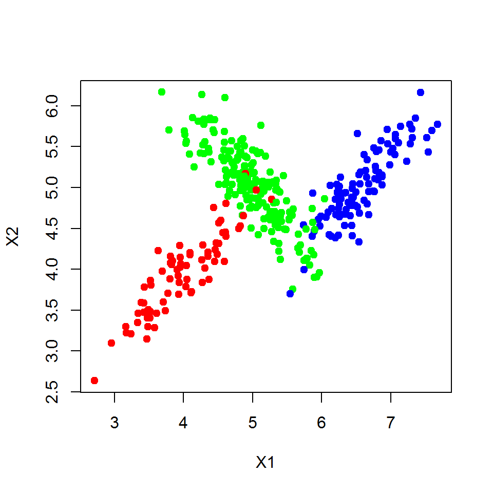

```r
plot(mydata, col=c("red","green","blue")[classes], xlab="X1", ylab="X2", pch=19)
```

But usually we do not know the details of the mixing process, so we only have the **incomplete dataset**:

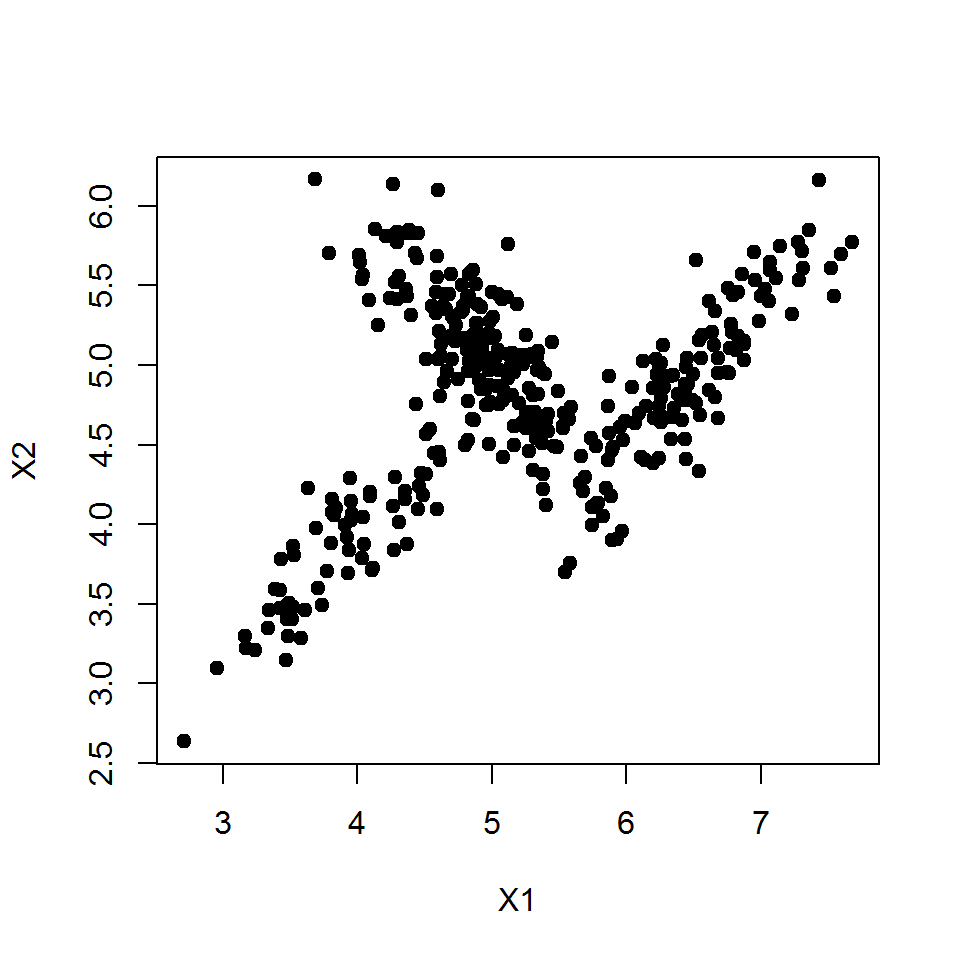

```r
plot(mydata, col="black", xlab="X1", ylab="X2", pch=19)
```

## The Model

If we decide to model the previous dataset as a mixture of $K$ Gaussians, then for a given datapoint $x$:

$p(x) = \sum_{i=1}^K p(K=i)p(x|K=i) = \sum_{i=1}^K \pi_k \mathcal{N}(x|\mu_k,\Sigma_k)$

is a superposition of $K$ Gaussians. Each density $\mathcal{N}(x|\mu_k,\Sigma_k)$ is a **component** of the mixture with its own mean and covariance matrix. The parameters $\pi_k$ are called the **mixing coefficients**, such that $\sum_k \pi_k = 1, \pi_k \geq=0$ ($\pi_k$ are probabilities).

An important value is $\gamma_k(x) \equiv p(K=k|x)$ which is called the **responsability** of Gaussian $k$ over datapoint $x$. By Bayes theorem,

$\gamma_k(x) \equiv p(K=k|x) = \frac{p(K=k)p(x|K=k)}{\sum_i p(K=i)p(x|K=i)} = \frac{\pi_k \mathcal{N}(x|\mu_k,\Sigma_k)}{\sum_i \pi_i \mathcal{N}(x|\mu_i,\Sigma_i)}$

The parameters of this model are $\pi \equiv \{\pi_1,\ldots,\pi_K\}$, $\mu \equiv \{ \mu_1,\ldots,\mu_K \}$ and $\Sigma \equiv \{\Sigma_1,\ldots,\Sigma_k\}$.

The log-likelihood of the dataset $X \equiv \{X_1,\ldots,X_N\}$ given the parameters is

$\log p(X|\pi,\mu\Sigma) = \sum_{n=1}^N \log \left\{ \sum_{k=1}^K \pi_k \mathcal{N}(x|\mu_k,\Sigma_k) \right\}$

Notice that there is not a closed-form analytic solution for the MLE. This is a good eg where the Expectation-maximization (EM) algorithm can find a numerical solution.

## The EM solution

We have an incomplete dataset $X$ with no information about which density produced each datapoint. Let’s call the parameters $\theta = \{\pi,\mu,\Sigma\}$.

So, we introduce a K-dimensional binary random variable $Z$, where each concretization $z$ consists of a vector of zeros except for one coordinate that has a one (eg for $K=5$, $z=(0,0,0,1,0)$). So, there are $K$ possible different states of $z$. Let’s call $z_k$ the k-th coordinate of $z$.

The marginal distribution is specified in terms of the mixing coefficient $p(z_k=1) = \pi_k \iff p(z) = \prod_{k=1}^K \pi_k^{z_k}$ since $z$ has zero everywhere else.

The conditional distribution of $x$ given a value $z$ is $p(x|z_k=1) = \mathcal{N}(x|\mu_k,\Sigma_k)$ which can be also stated as $p(x|z) = \prod_{k=1}^K \mathcal{N}(x|\mu_k,\Sigma_k)^{z_k}$

With these two distributions we can compute the joint distribution $p(x,z)$

$p(x,z) = p(x|z)p(z) = \prod_{k=1}^K ( \pi_k \mathcal{N}(x|\mu_k,\Sigma_k) )^{z_k}$

The marginal distribution of $x$ becomes

$p(x) = \sum_z p(z)p(x|z) = \sum_{k=1}^k \pi_k \mathcal{N}(x|\mu_k,\Sigma_k)$

which corresponds to the original mixing Gaussian model from the previous section. This means that this new model with latent variables $z$ is equivalent to the original model.

The advantage is that the original model could not be used with MLE, but this new model can be used in the [EM algorithm](http://www.di.fc.ul.pt/~jpn/r/EM/EM.html)!

The likelihood of the complete dataset $\{X,Z\}$ is

$p(X,Z|\theta) = \prod_{n=1}^N \prod_{k=1}^K ( \pi_k^{z_k} \mathcal{N}(x|\mu_k,\Sigma_k) )^{z_k}$

so the log-likelihood:

$\log p(X,Z|\theta) = \sum_{n=1}^N \sum_{k=1}^K z_k \left\{ \log \pi_k + \log \mathcal{N}(x|\mu_k,\Sigma_k) \right\}$ check and compare with the previous log-likelihood of incomplete dataset $X$; this one is much simpler for a MLE solution.

Using the formulas for marginal $p(z)$ and the conditional $p(x|z)$, and Bayes theorem, we can find the posterior distribution

$p(Z|X,\theta) \propto \prod_{n=1}^N \prod_{k=1}^K ( \pi_k^{z_k} \mathcal{N}(x|\mu_k,\Sigma_k) )^{z_k}$

The e-step of the EM is finding the value

$E_{Z|X,\theta} [ \log p(X,Z|\theta) ] = \sum_{n=1}^N \sum_{k=1}^K \gamma_k(x_i) \left\{ \log \pi_k + \log \mathcal{N}(x|\mu_k,\Sigma_k) \right\}$

For that we need to compute each responsability $\gamma_k(x_i)$ using the current parameter values $\theta$. To recall the expression:

$\gamma_k(x) \equiv p(K=k|x) = \frac{p(K=k)p(x|K=k)}{\sum_i p(K=i)p(x|K=i)} = \frac{\pi_k \mathcal{N}(x|\mu_k,\Sigma_k)}{\sum_i \pi_i \mathcal{N}(x|\mu_i,\Sigma_i)}$

The m-step fixes the responsabilities and maximizes the previous expected value wrt $\theta$. These updates have closed-forms (we do not to compute the expected value):

- $\mu_k = \frac{1}{N_k} \sum_{n=1}^N \gamma_k(x_i) x_n$
- $\Sigma_k = \frac{1}{N_k} \sum_{n=1}^N \gamma_k(x_i) (x_n - \mu_k)(x_n - \mu_k)^T$
- $\pi_k = \frac{N_k}{N}$
- $N_k = \sum_{n=1}^N \gamma_k(x_i)$

After an iteration (e-step plus m-step) we check if the parameters are within convergence tolerance, and if not, run another iteration.

## Fitting mixtures with R

The [package](http://cran.r-project.org/web/packages/mixtools/vignettes/mixtools.pdf) `mixtools` provides a set of functions for analyzing a variety of finite mixture models, and some functions use EM methods.

Herein, we use `mvnormalmixEM` which runs the EM algorithm for mixtures of multivariate normal distributions:

```r
library(mixtools)
model <- mvnormalmixEM(mydata, k=3, epsilon=1e-04)
```

```
## number of iterations= 28
```

```r
model$mu
```

```
## [[1]]
## [1] 4.950 5.068
##
## [[2]]
## [1] 3.946 3.906
##
## [[3]]
## [1] 6.499 4.945
```

```r
model$sigma
```

```
## [[1]]
##         [,1]    [,2]
## [1,]  0.1881 -0.1490
## [2,] -0.1490  0.1866
##
## [[2]]
##        [,1]   [,2]
## [1,] 0.2569 0.2072
## [2,] 0.2072 0.2108
##
## [[3]]
##        [,1]   [,2]
## [1,] 0.2336 0.2015
## [2,] 0.2015 0.2310
```

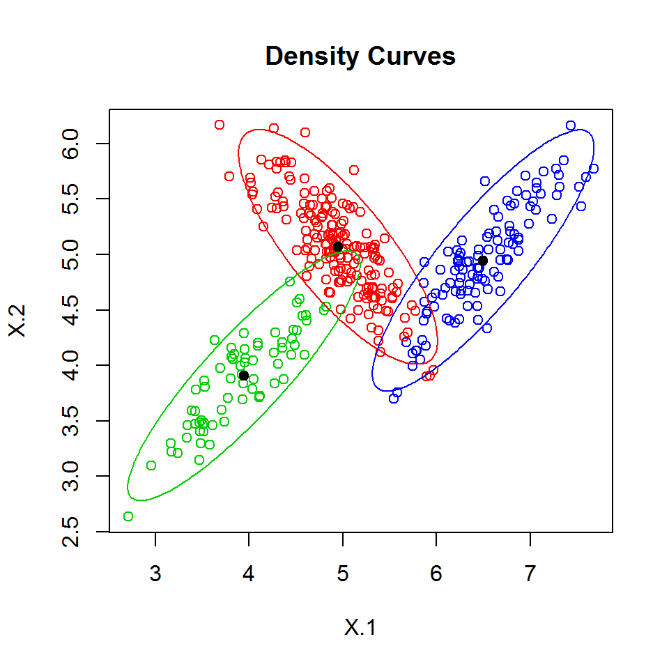

```r
plot(model, which=2)
```

```r
head(model$posterior)
```

```
##         comp.1    comp.2    comp.3
## [1,] 1.000e+00 8.452e-07 1.071e-21
## [2,] 9.709e-01 2.915e-02 3.560e-11
## [3,] 1.265e-12 2.190e-14 1.000e+00
## [4,] 3.337e-06 1.760e-11 1.000e+00
## [5,] 6.715e-01 3.285e-01 9.816e-08
## [6,] 9.830e-01 1.704e-02 3.338e-12
```

```r
pred <- apply(model$posterior, 1, function(row) which.max(row))
table(classes, pred)
```

```
##        pred
## classes   1   2   3
##       1   5  69   0
##       2 173   0  12
##       3   1   0 100
```

There is an error rate of 5% (the different number labels are meaningless). This is a consequence that the point clouds of different classes mix with each other, which simply cannot be recovered with this model (and, arguably, not by any other).